# Impact of household income on prevalence of health insurance in the US

31/10/2015

Source code for this report can be found at: https://github.com/mbh038/DASI/tree/master/Project

### Introduction:

Every country has the problem of how extensive a health care system should be, and how it should be funded. In the US, health care is at least in part funded by payment at the point of use through private health insurance taken out by the adult individuals who require care. The extent of care that can be given is determined by the coverage of the insurance policy. A clear issue arises, in that those on low incomes can afford less cover, and might also be tempted, indeed forced by financial hardship, to forego cover altogether. This study uses data from the American Elections Time Series study to investigate whether family incomes in households where individuals do not have health insurance are in fact lower than those of households where the individuals to have health cover.

This study tackles this issue in two ways. First, it asks:

**Is the mean income of US families within which individuals do not have health insurance lower than that of families where they do?**

It then asks the more detailed question of whether the proportion of households that have members without health insurance is correlated with the income bracket of the household.

### Data:

We use the American National Elections Time Series Study Coursera Extract data set, as provided on the [DASI course website:](https://d396qusza40orc.cloudfront.net/statistics%2Fproject%2Fanes1.html). This is an adaptation of the original data set which can be found at American National Election Studies ANES. The adaptation consists largely of removal of missing values and the creation of factor variables where appropriate.

Data were collected via the internet and via in-person (face-to-face interviews). Households for the latter were selected using an address-based, stratified, multi-stage cluster sample in 125 census tracts. Households for the former were selected using a combination of random selection of household by landline telephone number, and addressed based sampling, the latter method being introduced to account for the rising proportion of households, particularly among the young, that do not have a landline phone.

In total, information on 5914 individuals has been collected in this way.

In this data set the cases are the individuals that were contacted in this survey. They are all voters resident in the US. These could be split into subsets for each presidential election.

The two variables to be studied are income of the household of the individual and whether or not the individual had health insurance.

The first variable is logged as one of 28 categories, each of which has given lower and upper bounds for income range. For the first of our questions we will take the midpoint of this range as representative of the income for each category. Those who are in households where the income exceeds $250,000 (an unbounded category) will not be included in this analysis. For such high income households, there is little concern as to whether individuals in them have health insurance or not. If not, it is unlikely to be due to shortage of funds.

```r
df<-as.data.frame(cbind(as.numeric(anes$incgroup_prepost),anes$health_insured))
names(df)=c("income_cat","health_insured")
# remove NAs
df<-subset(df,is.na(df$income_cat)==FALSE & is.na(df$health_insured)==FALSE)
# remove those with incomes over $250000
df<-subset(df,df$income !=28)
```

```r
income=c(2500,7500,11250,13750,16250,18750,21250,23750,26250,28750,32500,37500,
          42500,47500,52500,57500,62500,67500,72500,77500,85000,95000,105000,
          117500,137500,162500,212500)

for (i in 1:nrow(df)) {
    df$income=income[df$income_cat]
}
```

Hence this variable will be treated in the analysis of the first question as numeric in nature.

The second variable is categorical in type, with categories “Yes” (I do have health insurance) and “No” ( I do not).

```r
s<-round(tapply(df$health_insured-1,df$income_cat,mean),3)
s
```

```
##     1     2     3     4     5     6     7     8     9    10    11    12
## 0.271 0.253 0.360 0.278 0.260 0.302 0.311 0.281 0.256 0.228 0.250 0.160
##    13    14    15    16    17    18    19    20    21    22    23    24
## 0.117 0.150 0.103 0.104 0.102 0.094 0.047 0.063 0.061 0.047 0.041 0.023
##    25    26    27
## 0.015 0.026 0.039
```

```r
sc<-sapply(split(df,df$income_cat),nrow)
sc
```

```
##   1   2   3   4   5   6   7   8   9  10  11  12  13  14  15  16  17  18
## 658 198 203  97 181  96 209 114 215  92 324 288 257 180 272 135 225 159
##  19  20  21  22  23  24  25  26  27
## 169 191 261 192 219 174 197 154 154
```

To account for inflation between elections, the household incomes could be normalised for each election by dividing by the mean and standard deviation of household incomes for whichever election the data were collected at. However we will not do this in this short study.

### Exploratory data analysis:

```
##    income_cat    health_insured     income
##  Min.   : 1.00   Min.   :1      Min.   :  2500
##  1st Qu.: 8.00   1st Qu.:1      1st Qu.: 23750
##  Median :14.50   Median :1      Median : 50000
##  Mean   :14.06   Mean   :1      Mean   : 60336
##  3rd Qu.:21.00   3rd Qu.:1      3rd Qu.: 85000
##  Max.   :27.00   Max.   :1      Max.   :212500
```

```
##    income_cat     health_insured     income
##  Min.   : 1.000   Min.   :2      Min.   :  2500
##  1st Qu.: 2.750   1st Qu.:2      1st Qu.: 10312
##  Median : 7.000   Median :2      Median : 21250
##  Mean   : 8.241   Mean   :2      Mean   : 29195
##  3rd Qu.:12.000   3rd Qu.:2      3rd Qu.: 37500
##  Max.   :27.000   Max.   :2      Max.   :212500
```

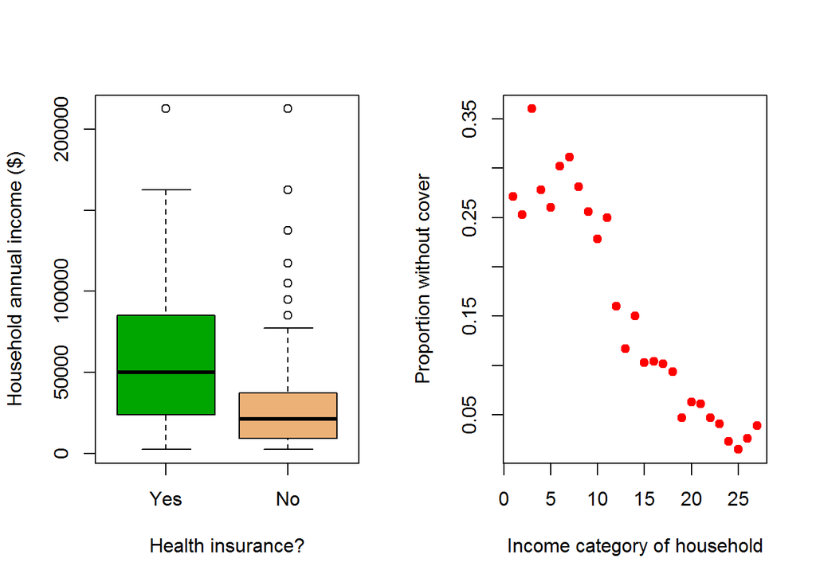

```r
par(mfrow=c(1,2))
boxplot(income~health_insured,
        data=df,
        names=c("Yes","No"),
        xlab="Health insurance?",
        ylab="Household annual income ($)",
        col=terrain.colors(3))
# legend("topright", inset=.02, title="health Insurance",
    #c("Yes","No"), fill=terrain.colors(3), horiz=TRUE,cex=0.7)
plot(s,
     pch=19,
     col="red",
     # main="Proportion of households without health cover",
     xlab="Income category of household",
     ylab="Proportion without cover")
```

Figure 1: (left) Distribution of household income as a function of whether or not all indiviudals in the household have health insurance. (right) Variation with income bracket of proportion of households without health insurance.

The boxplots in Figure 1 suggest data that is right skewed, as is common for incomes, and that the median income, at least, for households with health insurance is higher than that for households without it. The mean income for households where individuals have health insurance is $60335 while that for incomes where this is not the case is $29195 - just under half as big.

A plot of the proportion of households in which people live that do not have health insurance against income category (1 is lowest income, 27 is highest income) is shown in Figure 1 (b):

### Inference:

In this section, regarding our first question, we will establish the 99% condidence interval around one of the mean incomes, and see if it brackets the other mean income, and also evaluate how likely it is that one mean could be as far, or further, from the other as we find it to be if in fact level of health insurance ws not correlated with mean household income

When we calculate the 99% confidence interval around the mean income of households that do have health insurance, we find:

```r
ci99<-mean(insured$income)+c(-1,1)*qnorm(0.995)*sd(insured$income)/sqrt(nrow(insured))
ci99
```

```
## [1] 58481.58 62189.41
```

The mean annual income of households where individuals live that do not have health insurance is $29195 This is far below the 99% confidence interval of the mean income of the households where individuals do have cover. We can therefore infer, with at least 99% confidence, that the mean income of such households *IS* lower.

If we suppose a null hypothesis, Ho, that the mean income of households where lack of health insurance is found is the same as that of households where everyone has health cover, against an alternative hypothesis HA that the income is lower, then the p-value for this is:

```r
se<-sd(notInsured$income)/sqrt(nrow(notInsured))
zScore<-(mean(insured$income)-mean(notInsured$income))/se
pnorm(zScore,lower.tail=FALSE)
```

```
## [1] 4.076163e-218
```

This is effectively zero and so we can reject the null hypothesis at any reasonable level of significance. This result is consistent with the confidence interval we found above.

```r
h0<-sum(df$health_insured==2)/nrow(df)
h0
```

```
## [1] 0.162451
```

The chi-squared test statistic and degrees of freedom are given by

```r
Z<-sum((h0*sc-sc)^2/(h0*sc))
Z
```

```
## [1] 24242.11
```

```r
degF <- length(unique(df$income_cat)) -1
degF
```

```
## [1] 26
```

Hence the p-value for this test is:

```r
pchisq(Z,degF,lower.tail=FALSE)
```

```
## [1] 0
```

It is reasonable to use a chi-squared test here since there are many more than 5 observations in each income category, (the minimum number per category is 92 and we can reasonably assume independence between the counts in each category.

This is an observational study. The population of American voters has been randomly sampled, but not been randomly assigned to any groups or subjected to differing treatments depending on that assignation.

This study is of a large (>>30 subjects) sample that nevertheless forms a small proportion (<<10%) of the population from which it was drawn. These subjects were randomly selected. Hence the central limit theorem should apply even if the sub-sample (insured or not insured for health) income distributions are right skewed, as income distributions generally are. Hence we can generalise from the results of this sample to the population as a whole.

Bias may occur in the selection of the sample, if this is not truly random. Significant efforts were made to avoid this, as explained in the code book, for example to not exclude those households that do not have a landline telephone.

However, even if the sample is truly random, it is a sample of voters in the US. Therefore it may not be representative of non-voters in the US, and hence, is not not necessarily representative of all individuals actually present in the US.

Since this study is observational, it cannot establish a causal relationship between household income and the likelihood of individuals in that household having health insurance. It can only establish correlation between these two, if any.

### Conclusion:

From the analysis above we can conclude that there is indeed a correlation between household income and whether or not individuals in the household have health insurance. This is born out by the chi-squared test: a p-value close to zero means that we can confidently reject the null hypothesis that the proportion of households in which people live who have no health cover is independent of the income bracket of that household.

There is no easy solution to finding a workable model for health care for all, but this analysis shows that a case can be made that, in the US, many low income households do not have the access to health care enjoyed by higher income households.

This study has not sought to find out whether the results have changed with time. A further study could address this and separately analyse individuals surveyed at each of the several elections included in the data set.

### References:

We use the American National Elections Time Series Study Coursera Extract data set, as provided on the [DASI course website:](https://d396qusza40orc.cloudfront.net/statistics%2Fproject%2Fanes1.html). This is an adaptation of the original data set which can be found at American National Election Studies ANES. The adaptation consists largely of removal of missing values and the creation of factor variables where appropriate.

### Appendix:

Here are the first 20 rows of the data used, showing the income category (1-27) of the household of the individual, whether or not (Yes:1, No:2) the individual had health insurance, and the middle value of the annual income of the income category, in US$.

```r
head(df,20)
```

```
##    income_cat health_insured income
## 1           2              1   7500
## 2           7              1  21250
## 3           3              1  11250
## 4           2              1   7500
## 5          13              1  42500
## 6           2              1   7500
## 7           1              1   2500
## 8           1              1   2500
## 9          11              1  32500
## 10          9              1  26250
## 11         27              1 212500
## 12         27              1 212500
## 13         24              1 117500
## 14         15              1  52500
## 15         25              1 137500
## 16          1              1   2500
## 17         26              1 162500
## 18          7              1  21250
## 19          1              2   2500
## 20          7              1  21250
```